# Week 2

Introduction to Data Science in Health and Social Care HEIN11037

Dr Brittany Blankinship

## Audio Check

## Asking Questions

## Recording

# Week 2 Tutorial

Introduction to Data Science in Health and Social Care HEIN11037

## Agenda

- Course updates
- Data Science process
- Introducing R
- Example data flow presentation using health data
- Tips for starting out with R
- How to search for help online

## How are you feeling today?

On this animal scale

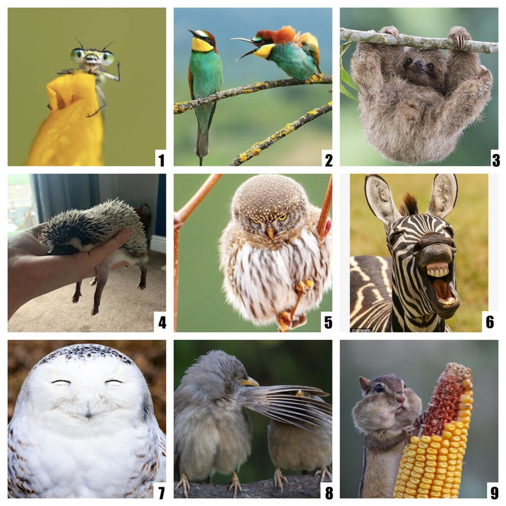

## Health and Data Science Hub

Have you been able to access the **induction space** on Learn?

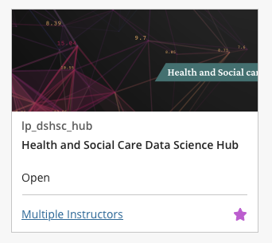

## 3 Stars and a Wish ⭐⭐⭐🚀

- Post your 3 stars and 1 wish at the end of each week to get points
- 10% of your final grade. 10 posts across 10 weeks
- All 10 are due at the end of the course on 7 December 2026 2pm GMT
- Replying to your peers is encouraged, but you will only get the points when you post your own reflections from the week

## Drop-in this week

> Friday, 2 October 10am BST

Drop in to…

- Discuss the course content so far
- Learn from the questions your peers ask
- Chat with the teaching team
- Troubleshoot anything related to R
- Work through the course content with the teaching team on hand to answer any questions

## General feedback from last week

**Discussion Boards**

- In-line references are good (and better than references just collected at the end), but it’s often even better if some concrete piece of referenced information is reproduced in the text.
- This is what demonstrates *critical engagement* with the referenced sources

# The Data Science Process

## A simplified way of thinking about the data science process:

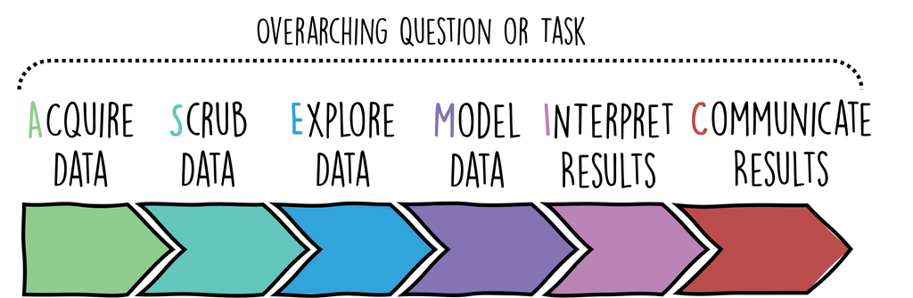

Figure by Florian Huber, 2026

## Another condensed way of thinking about the data science process

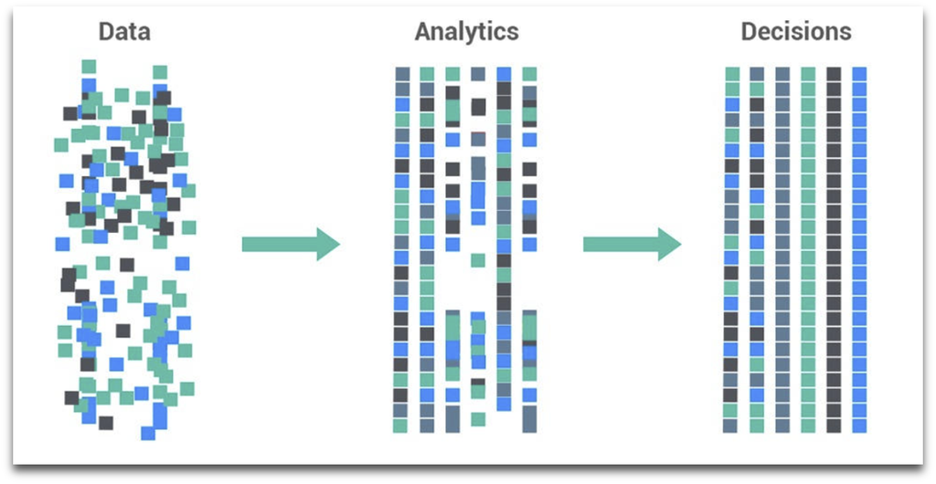

## ASEMIC Data Science Process

Captures the essence of a typical data science project. Crucially, while presented linearly, **real-world data science is an iterative, cyclical process**

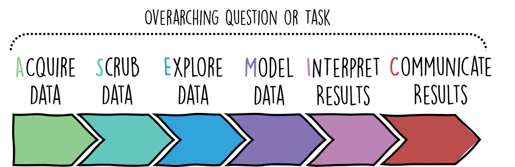

Figure by Florian Huber, 2026

## Data Science Workflow

The data science process consists of a wide variety of **different phases or steps**, which ultimately also leads to the wide **variety of techniques and tools** that need to be used throughout such a process.

- different skills and expertise are required for different phases of a typical data science project

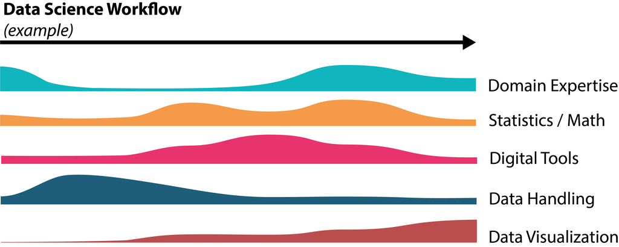

Figure by Florian Huber, 2026

## Data Science is Science ⚖️ 🔍

⚖️ You might be used to science looking like this:

- theory > hypothesis > data
- This is **confirmatory analysis**, a **deductive** approach to knowledge
- Asks: “Is this specific hypotheses supported by the data?”

## Data Science is Science ⚖️ 🔍

When doing data science projects, we are often using data we did not collect where we do not have to context to be testing pre-defined hypothesis.

What do we do?

# Explore! 🔍

## Exploratory Data Analysis 🔍

Finds patterns and generates new hypotheses from data

- data > patterns > theory
- This is an **inductive** approach to knowledge that generates hypotheses and leads to open-ended discovery
- Asks: “What does the data suggest?”

## Successful exploratory analysis starts with **context**

- *not* data visualisation or narrative, these come later
- in this course we are learning about and using *data storytelling* techniques

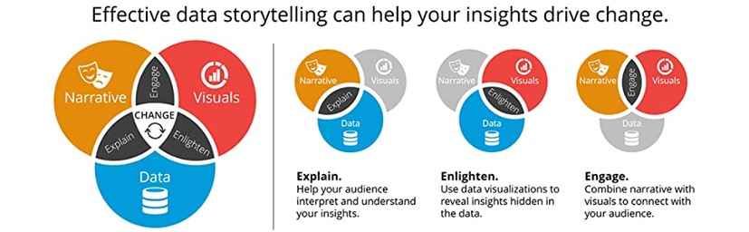

Image by Brent Dykes

## Data storytelling: a brief introduction

Begin with the context around the need to communicate

- understand the circumstances around each metric in a given data set
- transition from data discovery (**exploratory analysis**) to data communication (**explanatory analysis**)

## After exploring the data, move to explanatory thinking

- Exploration = observing patterns
- Before finalising data visualisations & composing your narrative, you must consider
  1. Who is your audience?
  2. Who do you need your audience to know or do?
  3. How will you communicate to your audience?

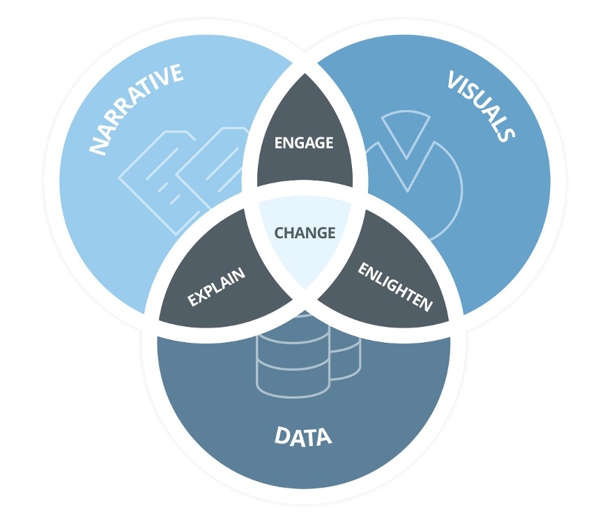

# Building your data scientist tool kit ⚒️ 🛠️

# Have you downloaded R + RStudio, or are you using Noteable?

## Organisations Behind R

1. The R Project
2. The R Foundation
3. Comprehensive R Archive Network (CRAN)
4. Posit (rebranded from RStudio in November 2022)

[figure not shown]

### **Advantages**

- Open Source Software
  - Free!!
- New methods implemented faster
- More flexible/customizable
- Anyone can contribute
  - Do not have to work at R to contribute to R

### **Disadvantages**

- No centralised support
- Many find it harder to learn - but that is why we are here!
- Less consistency across procedures - other software you rely on the programmers
- …Anyone can contribute (some packages are better than others)

## Further (selected) reasons why R!

- High quality and robust data visualisation
  - e.g., `{ggplot2}` — covered in depth in week 6
- Go-to language for statistics and data science; used in almost every industry
- Vast R community support
  - Stack Overflow
  - #Rstats on social media
  - etc.
- The most comprehensive statistical analysis package, new technology & ideas open appear first in R
- The `{tidyverse}` ecosystem
- You can do many things beyond data analysis/processing…maps, calendars, etc.!
- It can be very satisfying and fun once you get the hang of it!

## Into the `{tidyverse}`!

> Streamlined data wrangling and data visualisation

[figure not shown]

## Into the `{tidyverse}`!

A formalised set of packages and tools that have a consistently structured programming interface

- as opposed to base R which is more complex/varied and less user friendly

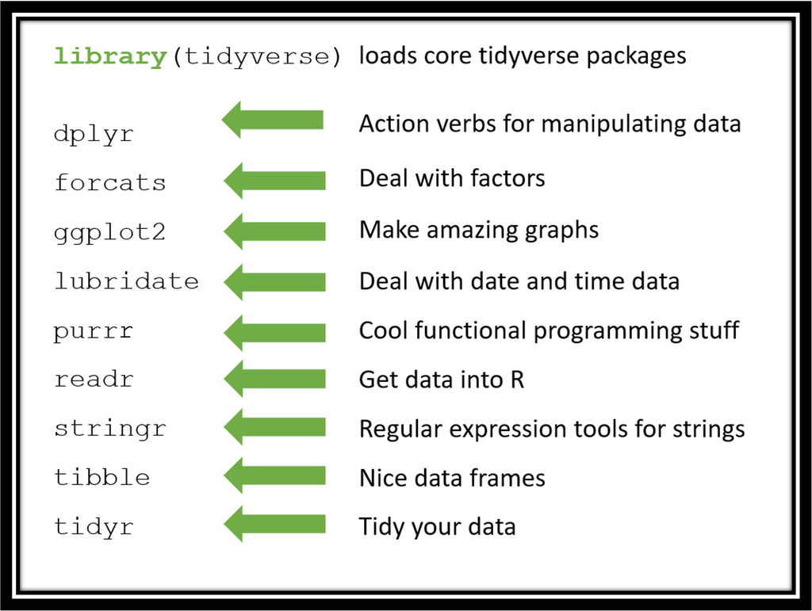